# Tutorial de Reprodutibilidade

Nete Barreto

2025-12-09

## Resumo

O pacote **reprodutibilidade** foi desenvolvido para apoiar as etapas de elaboração dos indicadores da plataforma **AdaptaBrasil**. Como o processo de criação dos índices e indicadores envolve diversas fases — incluindo validação e análises estatísticas — o pacote oferece funções que facilitam a criação, verificação e divulgação dos resultados de forma rastreável e reprodutível.

## Introdução

O fluxograma apresentado ilustra o fluxo de tratamento e preparação dos dados dentro do processo analítico da plataforma AdaptaBrasil. Ele representa a sequência de etapas aplicadas aos dados brutos antes da execução das análises estatísticas e da construção dos indicadores.

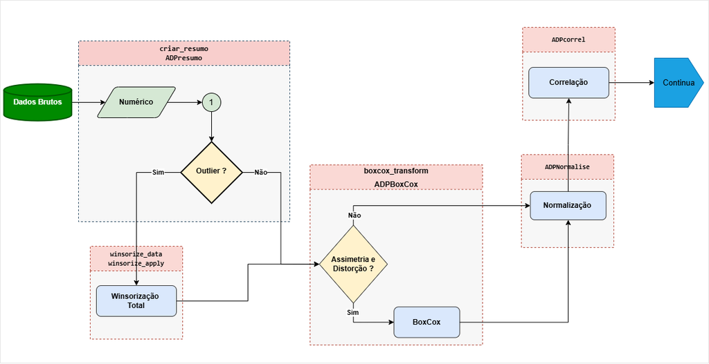

Figura 1: Fluxo de tratamento e preparação dos dados brutos, incluindo etapas de verificação, transformação e normalização para garantir consistência e reprodutibilidade estatística.

O processo inicia com a verificação do tipo de variável, diferenciando dados do tipo Score de variáveis numéricas. Para variáveis numéricas, ocorre a identificação de outliers e, se necessário, aplica-se a winsorização, que reduz o impacto de valores extremos sem removê-los. Em seguida, os dados são avaliados quanto à assimetria e curtose, de modo a identificar distorções na distribuição. Quando essas distorções são significativas, utiliza-se a transformação Box-Cox, que corrige desvios de normalidade e estabiliza a variância.

Após o ajuste da distribuição, os dados passam pela normalização, permintido a comparabilidade entre diferentes variáveis e unidades de medida. Por fim, realiza-se a análise de correlação, que permite avaliar as relações entre os indicadores e seguir para as etapas subsequentes de modelagem e composição dos índices.

Esse fluxo propricia reprodutibilidade e consistência estatística dos dados processados, consolidando a qualidade das informações analisadas. Para iniciar, é necessario instalar o pacote disponivel no GitHub, sendo inicialmente desenvolvido em ambiente windows 11.

```r
devtools::install_github("AdaptaBrasil/reprodutibilidade")
```

## Carregando o pacote

```r
require(reprodutibilidade)
```

## Lendo arquivos de entrada

```r
library("reprodutibilidade")

inxlsx <- openxlsx::loadWorkbook(file = "DATASET/Base_inicial_SA_Acesso.xlsx")
```

Lendo as planilhas do arquivo, nesse caso a planilha metadados, contem as informações sobre os indicadores que serão analisados como:

- **N** - Contador simples.
- **NIVEL** - Nivel do Índice/Indicador.
- **CODE** - Sigla para indexação do Índice/Indicador.
- **NOME** - Descrição completa do título do Índice/Indicador.
- **TIPO** - Categoria do Índice/Indicador.
- **PAI** - Informa a qual Índice/Indicador está relacionado no nível acima.
- **CLASSE** - Informa a categoria que serão aplicadas as operações. Se *Numerico* operações padrões, se *Descrição* utilizado apenas para indexação.

[figure not shown]

```r
  library("reprodutibilidade")

  resultado <- read_exemplo_xlsx()
```

```
##
##  Arquivo de exemplo 'Base_inicial_SA_Acesso.xlsx' carregado com sucesso!
```

```
##  O arquivo foi lido a partir do pacote 'reprodutibilidade'.
```

```
##  As planilhas disponiveis sao: 'metadados' e 'dados_SA_Acesso'.
```

```
##  Acesse-as com: resultado$metadados ou resultado$dataset
```

```r
  metadados <- resultado$metadados
  dataset  <- resultado$dataset

  # Recortando apenas os dados do Nivel 7
  metadadosN7 = subset(metadados,metadados$Nivel==7)

  # Selecionando apenas as referencias
  data_ref = dataset[,c(1:3)]

  # Selecionando todos os dados
  datasetN7 = round(dataset[,-c(1:3)],2)

  #Atribuindo nome as colunas
  colnames(datasetN7) <- colnames(dataset[,-c(1:3)])
```

## Aplicando as Funções Básicas

### *Resumo*

#### criar_resumo*(dataset, class_type, nome)*

Essa função obtem estastitiscas básicas de apenas um único indicador, para executar o cálculo de forma correta, atentar para objeto *class_type* que se refere a classe do objeto, sendo um objeto *Numérico* é a escrita deve ser a seguinte: **“Numerico”**.

```r
library("reprodutibilidade")

# Carregando a base de dados de exemplo
data("datasetN7", package = "reprodutibilidade")

idx_MMPD = datasetN7$MMPD
nome = "MMPD"

res1 = criar_resumo(idx_MMPD,"Numerico" , "MMPD")
```

```
##     Nome  Classe
##   1 MMPD  Numerico
```

```r
print_summary(res1)
```

```
##
##   Resumo Estatistico da Variavel
##
##  Variavel: MMPD
##  Classe: Numerico
##
## Min                  : 2.33
## Quartil 1            : 2.89
## Mediana              : 3.09
## Quartil 3            : 3.36
## Max                  : 4.06
## Outliers_Per         : 3.99
## NAs                  : 5
## Percentual_NAs       : 0.09
## Valores_Unicos       : 278
## Percentual_Unicos    : 5
##
```

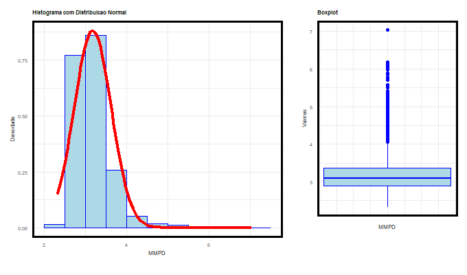

```r
criar_grafico(idx_MMPD, plot=TRUE, nome_arquivo = "grafico_combinado.png",
              largura = 10, altura = 5, dpi = 25,
              nvalores="MMPD",fsize=6)
```

#### ADPresumo *(dataset, class_types, clusters, nomes)*

A função *ADPresumo(dataset, class_types, clusters, nomes)* executa a geração padronizada de resumos descritivos para cada variável de um conjunto de dados.

O procedimento interno da função envolve:

- Verificação da consistência entre o número de colunas do dataset e os vetores informados;
- Resumir as medidas descritivas de cada variavel;
- Combinação dos resultados em um único quadro (resumo_combinado);

Gerando três objetos de saída:

- *resumo_total*: resumo completo de todas as variáveis;
- *resumo_basico*: tabela transposta com estatísticas principais;
- *resumo_na*: resumo focado em valores ausentes.

```r
library("reprodutibilidade")
# Carregando a base de dados de exemplo

# Metadados
data("metadadosN7", package = "reprodutibilidade")

# Dataset
data("datasetN7", package = "reprodutibilidade")

# Dataset referencia
data("data_ref", package = "reprodutibilidade")

resumo <- ADPresumo(datasetN7,
                    metadadosN7$CLASSE,
                    colnames(datasetN7))
```

```
##
##  Resumo Geral Obtido
```

```r
print(resumo$resumo_total)
```

```
## # A tibble: 22 × 12
##    Nome    Classe   Min `Quartil 1` Mediana `Quartil 3`   Max Outliers_Per   NAs
##    <chr>   <chr>  <dbl>       <dbl>   <dbl>       <dbl> <dbl>        <dbl> <int>
##  1 MMPD    Numer…  2.33        2.89    3.09        3.36  4.06         3.99     5
##  2 MCFSFC… Numer…  0           0.06    0.1         0.13  0.23         1.51     5
##  3 PED(CI) Numer… 29.2        44.9    49.6        56.9  74.8          1.92     5
##  4 DRDAFD  Numer…  0           0.11    0.22        0.37  0.76         1.71     0
##  5 QA      Numer…  5           5       5           5     5           12.3   2605
##  6 DCAU10… Numer…  0           0.69    4.1        11.2  27.0          3.16     2
##  7 SRAAB   Numer…  0.02        0.29    0.4         0.47  0.74         8.1      0
##  8 NIAN    Numer…  0.2         0.2     0.6         0.6   1            0        5
##  9 PCM2AD  Numer…  0           0       0.28        0.81  2.02         5.6      0
## 10 ODRSAI  Numer…  0           0.27    1.3         3.6   8.59         5.89     0
## # ℹ 12 more rows
## # ℹ 3 more variables: Percentual_NAs <dbl>, Valores_Unicos <int>,
## #   Percentual_Unicos <dbl>
```

### *Winsorization*

Essas funções tem como objetivo reduzir o impacto dos valores extremos (*outliers*) do conjunto de dados, reprojetando os mesmos para valores próximos a limiares baseados nos percentis inferiores e superiores de cada variável.

#### winsorize_info(*indice, classe_label = NULL, var_name=NULL*)

```r
library("reprodutibilidade")

# Carregando a base de dados de exemplo
data("metadadosN7", package = "reprodutibilidade")

data("datasetN7", package = "reprodutibilidade")

idx_MMPD = datasetN7$MMPD
nome = "MMPD"

res1 = winsorize_info(idx_MMPD,"Numerico" , "MMPD")

print_summary(res1)
```

```
##
##   Resumo Estatistico da Variavel
##
##
## nome                 : MMPD
## classe               : Numerico
## winsorize            : S
## linf                 : 2.33
## lsup                 : 4.06
## n_outlier            : 222
## n_na                 : 5
##
```

#### winsorize_data( *dataset*, *metadados*)

```r
winsorize_data(dataset = datasetN7,
               metadados = metadadosN7)
```

```
##
##  Resumo Winsorize Criado
```

```
##              nome   classe winsorize  linf   lsup n_outlier n_na
## 1            MMPD Numerico         S  2.33   4.06       222    5
## 2        MCFSFCBR Numerico         S     0   0.24        84    5
## 3         PED(CI) Numerico         S 29.17  74.85       107    5
## 4          DRDAFD Numerico         S     0   0.76       103    0
## 5              QA Numerico         N     5      5       686 2605
## 6      DCAU10MILH Numerico         S     0  26.98       176    2
## 7           SRAAB Numerico         A  0.02   0.74       451    0
## 8            NIAN Numerico         I   0.2      1         0    5
## 9          PCM2AD Numerico         S     0   2.03       312    0
## 10         ODRSAI Numerico         S     0    8.6       328    0
## 11            NSP Numerico         A  0.23   0.71        39    0
## 12      IFPCPESIA Numerico         S     0   0.99       163    0
## 13          IPGSA Numerico         S  0.08   0.73       149    5
## 14          APNAE Numerico         S     0 130.77        78    7
## 15 NAPURPAATSASMC Numerico         S     0   0.18       146 4433
## 16        FPAAPCT Numerico         N     0    100         0 2728
## 17       NAPCP1MC Numerico         S     1 2110.5        78 4216
## 18           APBF Numerico         A  0.11   1.68        36    5
## 19           IDRD Numerico         S     0   0.29        71   10
## 20       DRPCS5SM Numerico         S     0  40.26        78   10
## 21             DP Numerico         S  0.13 111.84       647    5
## 22             PT Numerico         S  0.01   0.39       425    0
```

```r
data_winsor <- winsorize_apply(dataset=datasetN7,
                              metadados=metadadosN7)
```

```
##
##  Resumo Winsorize Criado
```

```
##
##  Winzorize aplicado no dataframe
##
##
```

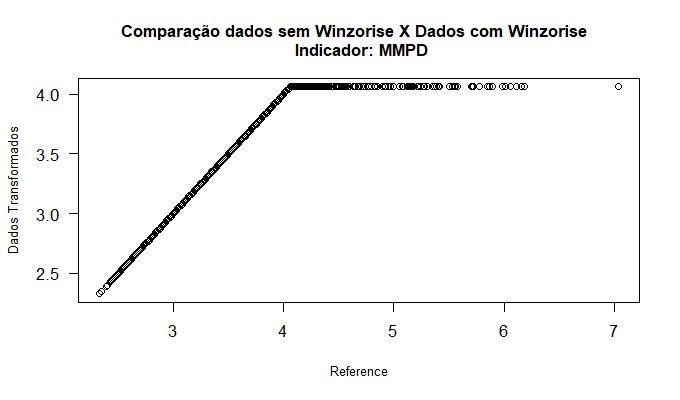

```r
plot(idx_MMPD,data_winsor$dataset$MMPD,
      main = paste0("Comparação dados sem Winzorise X Dados com Winzorise  \n Indicador: ",nome),
      cex.axis=1,las=1,ylab="Dados Transformados",
      xlab="Reference", cex.lab=0.8,cex.main=1)
```

### *BoxCox*

Essa função aplica da trnasformada BoxCox buscando corrigir assietria e estabilizar a variância, aproximando de uma distribuição normal.

#### boxcox_transform(*value, metodo=c(“forecast”, “COINr”, “yeojohnson”)*)

```r
library("reprodutibilidade")

# Carregando a base de dados de exemplo
data("metadadosN7", package = "reprodutibilidade")
data("datasetN7", package = "reprodutibilidade")

dados <- datasetN7[,19]

# Aplicando Box-Cox com pacote forecast
bxcx.fcs <- boxcox_transform(dados, metodo = "forecast")
```

```
## Box-Cox aplicado com metodo: forecast
```

```r
# Aplicando Box-Cox com o COINr
bxcx.coin <- boxcox_transform(dados,metodo = "COINr")
```

```
## Box-Cox aplicado com metodo: COINr
```

```r
# Aplicando Yeo-Johnson
bxcx.yjn <- boxcox_transform(dados, metodo = "yeojohnson")
```

```
## Box-Cox aplicado com metodo: yeojohnson
```

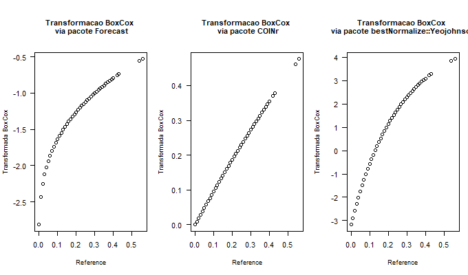

```r
par(mfrow=c(1,3)) ; par(mar=c(5,4,6,1))

 plot(sort(dados),sort(bxcx.fcs),
      main = "Transformacao BoxCox \n via pacote Forecast",
      cex.axis=1,las=1,ylab="Transformada BoxCox",
      xlab="Reference", cex.lab=0.8,cex.main=1)

 plot(sort(dados),sort(bxcx.coin),
      main = "Transformacao BoxCox \n via pacote COINr",
      cex.axis=1,las=1,ylab="Transformada BoxCox",
      xlab="Reference",cex.lab=0.8,cex.main=1)

 plot(sort(dados),sort(bxcx.yjn),
      main = "Transformacao BoxCox \n via pacote bestNormalize::Yeojohnson",
      cex.axis=1,las=1,ylab="Transformada BoxCox",
      xlab="Reference",cex.lab=0.8,cex.main=1)
```

#### ADPBoxCox(*dadoswin=NULL, dados_originais=NULL, classe=NULL, nome=NULL, metodo=NULL*)

```r
method_boxcox = "forecast"

data_bxcx <- ADPBoxCox(dadoswin=data_winsor$dataset,
                      dados=datasetN7,
                      classe=metadadosN7$CLASSE,
                      nome=colnames(datasetN7),
                      metodo=method_boxcox)
```

```
## Box-Cox aplicado com metodo: forecast
```

```
##
##  BoxCox aplicado no dataframe
##
##
```

### *Normalização*

#### ADPNormalise(*iData*)

```r
data_normal <- ADPNormalise(data_bxcx$data)
```

```
##
##  Normalizacao Aplicada no data.frame
```

### *Tratamento*

#### Tratamento(*input=“INPUT.xlsx”, metadados = “Plan_Metadados”, dataset = “Plan_Dados”, method_boxcox = NULL, sigla=NULL, subsetor=NULL*)

Excutando a função que aplica as métricas, Cria uma lista chamado result, onde estão os resultados das metricas aplicadas.  
Salvando em dois (2) arquivos .xlsx no diretório OUTPUT

- O primeiro ANALISE_DESCRITIVA_SETOR_DATA_HORA.xlsx
- O segundo DADOS_TRATADOS_SETOR_DATA_HORA.xlsx

```r
caminho_arquivo <- system.file("dataset",
                               "Base_inicial_SA_Acesso.xlsx",
                                package = "reprodutibilidade")

result = Tratamento(input=caminho_arquivo,
                    metadados = "metadados",
                    dataset = "dados_SA_Acesso",
                    nivel=7,
                    method_boxcox="forecast",
                    sigla = "SE",
                    subsetor= NULL)
```

```
##
##  Resumo Geral Obtido
```

```
##
##  Resumo Winsorize Criado
```

```
##
##  Winzorize aplicado no dataframe
##
##
```

```
## Box-Cox aplicado com metodo: forecast
```

```
##
##  BoxCox aplicado no dataframe
##
##
```

```
##
##  Normalizacao Aplicada no data.frame
```

```
##
##  Arquivos .xlsx Gerados
##   ANALISE_DESCRITIVA_SE_2025-12-09_18h43m.xlsx
##   DADOS_TRATADOS_SE_2025-12-09_18h43m.xlsx
```

## Visualização dos Resultados

### Mapas

Observações importantes das funções de criação dos mapas:

- Caso o nome do arquivo não seja definido, a função fará com que o nome do mesmo seja a combinação do *iNome* e do *DADOS*, ex:
  - iNome = “MMPD” e
  - DADOS = datasetN7
  - nome_arquivo = MMPD_datasetN7.png ;
- Caso o diretório de salvamento do arquivo não seja definido, o arquivo será salvo no local de execução;

Sugestão antes de executar, criar o diretório **FIG**, na função inserir **dir = “FIG”**, dessa maneira a função irá salvar a imagem diretamente nesse diretório.

- Caso as definições das dimenções da imagem não seja determinada a imgem final será gerada com as seguintes definições padrão em *px*:
  - largura = 20
  - altura = 24
  - dpi = 300

### *Mapas Não Normalizados*

#### map_result*(iNome, DADOS, REFERENCE, titulo = “Titulo”, shp_mun = NULL, shp_uf = NULL, salvar = FALSE, dir = NULL, nome_arquivo = NULL, largura = 20, altura = 24, dpi = 300, fsize = 16)*

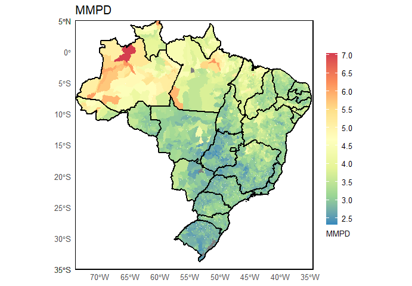

```r
library("reprodutibilidade")

map_result("MMPD", datasetN7, data_ref, fs = 10, titulo = "MMPD")
```

### *Mapas Normalizados*

#### map_result*(iNome, DADOS, REFERENCE, titulo = “Titulo”, shp_mun = NULL, shp_uf = NULL, salvar = FALSE, nome_arquivo = “map_N7.png”, largura = 20, altura = 24, dpi = 300, fsize = 16)*

[figure not shown]

```r
map_result_normal("MMPD", result$Data_Normal$dataset, data_ref,
                  fs = 10,
                  titulo = "MMPD")
```

### Apresentação do Resumo

#### slides_descricao*( result, icode, titulo = NULL, caminho_arquivo = “saida_apresentacao.pptx”, caminho_imagem = NULL, caminho_map = NULL)*

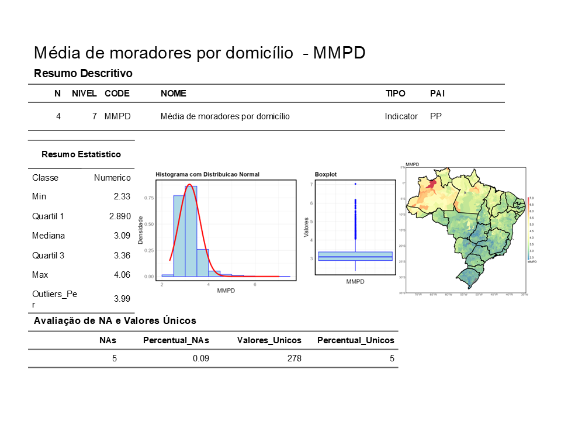

Figura 3: Exemplo do slide resumo gerado inserido na apresentação diretamente.

```r
# definindo o caminho da base de dados no formato .xlsx
  caminho_arquivo <- system.file("dataset",
                               "Base_inicial_SA_Acesso.xlsx",
                                package = "reprodutibilidade")

# gerando os resultados e salvando em .xlsx
  result = Tratamento(input=caminho_arquivo,
                      metadados = "metadados",
                      dataset = "dados_SA_Acesso",
                      nivel=7,
                      method_boxcox="forecast",
                      sigla = "SE",
                      subsetor= NULL)

# Determinado o indicador que será apresentado
  icode <- tab.descricao$CODE

# Criando os gráficos de resumo
  criar_grafico(result$DadosB[[icode]],
                plot=FALSE,
                nome_arquivo = "grafico_combinado.png",
                largura = 10, altura = 5, dpi = 100,
                nvalores="MMPD", fsize=18)

# Gerando a figura do mapa

  map_result(icode,
             result$DadosB,
             result$Ref,
             fs = 30,
             Titulo = icode,
             salvar=TRUE)

  slides_descricao(result, icode,
                   titulo=NULL,
                   caminho_arquivo = "saida_apresentacao.pptx",
                   caminho_imagem  = "grafico_combinado.png",
                   caminho_map     = "map_N7.png")
```

### Apresentação do Winsorization

#### slides_process*( tabela1, process = NULL,titulo = “Titulo do Slide”, caminho_arquivo = “saida_apresentacao.pptx”, caminho_map = NULL)*

[figure not shown]

Figura 4: Exemplo do slide winsorizatin gerado inserido na apresentação diretamente.

```r
  map_result(icode,
             result$Data_Win$dataset[1,],
             result$Ref,
             fs = 30,
             Titulo = icode,
             salvar=TRUE)

  slides_process(
    result$Data_Win$resumo[1,],
    process         = "winsorize"
    titulo          = "Tabela Gerada no R",
    caminho_arquivo = "slide_process_winsorize.pptx",
    caminho_map     = "arquivo_mapa.png")
```

### Apresentação do BoxCox

#### slides_process*( tabela1, process = NULL,titulo = “Titulo do Slide”, caminho_arquivo = “saida_apresentacao.pptx”, caminho_map = NULL)*

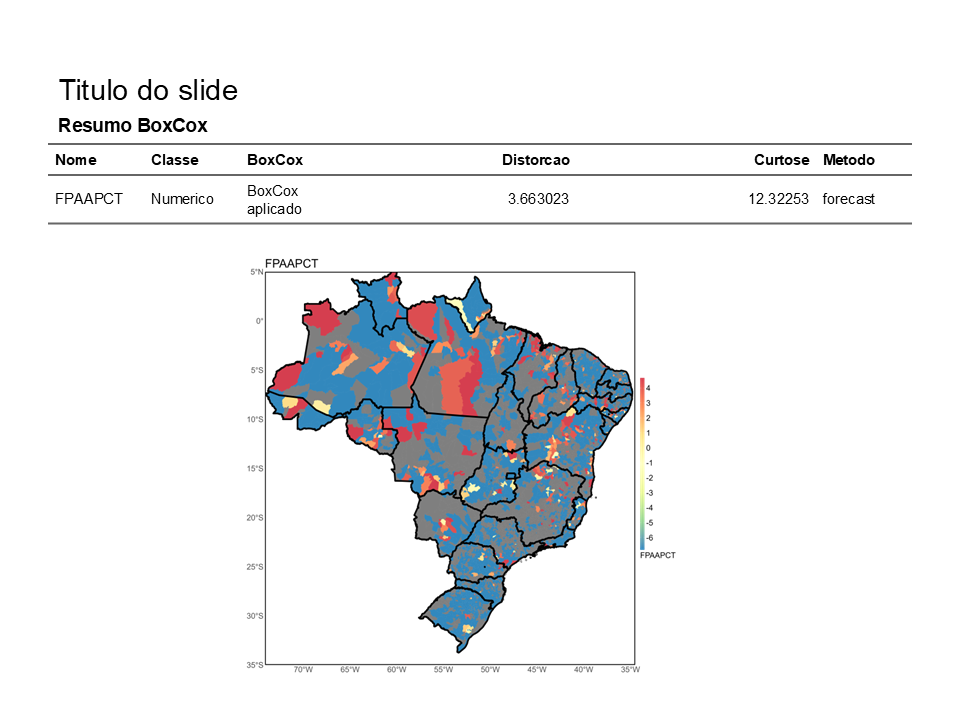

Figura 5: Exemplo do slide gerado com a base de dados do boxcox inserido na apresentação diretamente.

```r
  map_result("FPAAPCT", result$Data_Bxc$data, result$Ref,
              fs     = 26,
              titulo = "FPAAPCT",
              salvar = TRUE)

 slides_process(result$Data_Bxc$meta[16,],
                process         = "BoxCox"
                titulo          = "Titulo do slide",
                caminho_arquivo = "saida_apresentacao_bxcx.pptx",
                caminho_map     = "FPAAPCT_result$Data_Bxc$data.png")
```

## Aplicando as Funções Análise

### *Correlação*

#### total_na*(indice)*

```r
total.na(datasetN7$MMPD)
```

```
## [1] 5
```

#### get_max_cor *(var_name,cor_matrix=NULL)*

```r
mat <- cor(mtcars)

get_max_cor("mpg", mat)
```

```
##            max_pcor             var_max
## "0.681171907806749"              "drat"
```

#### ADPcorrel*(x)*

```r
res <- ADPcorrel(result$Data_Normal$dataset)

head(res$cor_summary)
```

```
##            Cor_Max             Cor_Par
## MMPD       "0.650869856375549" "PED(CI)"
## MCFSFCBR   "0.665934427027578" "PED(CI)"
## PED(CI)    "0.799845828299096" "DRPCS5SM"
## DRDAFD     "0.381128913409374" "DP"
## QA         "0.24205585883426"  "DP"
## DCAU10MILH "0.534066700481322" "DRPCS5SM"
```

#### correl_ind*(x)*

```r
result_cor <- correl_ind(result$Data_Normal$dataset)
```

```
##
##    Metricas de Avaliacao Calculadas.
```

```r
head(result_cor$Resumo)
```

```
##    Indicador Cor_Max Cor_Par_Indicador      Sugestao_Remocao
## 1       MMPD   0.652           PED(CI) Remover (Correl alta)
## 2   MCFSFCBR   0.667           PED(CI) Remover (Correl alta)
## 3    PED(CI)   0.800          DRPCS5SM Remover (Correl alta)
## 4     DRDAFD   0.378                DP                Manter
## 5 DCAU10MILH   0.534          DRPCS5SM                Manter
## 6      SRAAB   0.335                DP                Manter
```

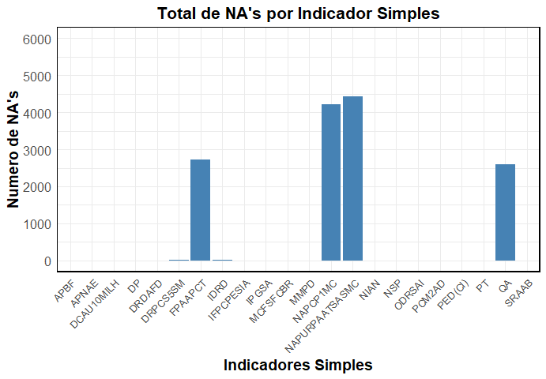

```
##
##        Figura de Contagem de NA's Gerada
```

```r
FigContNA(result_cor$Contagem_NA,
          nfile="Contagem_NA_ISimples.png",
          visivel=TRUE)
```

#### FigCorrelPlot*(result_cor$Correl,tipo=“Total”,nfile=“FIGs/Correlação_Total.png”)*

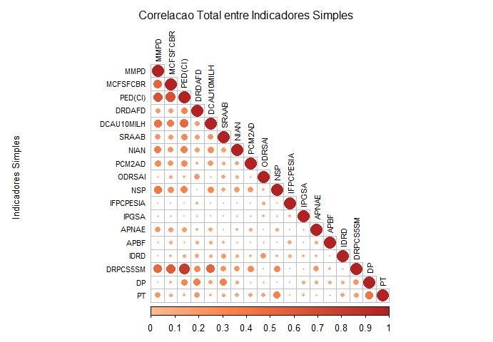

```
##
##        Figura de Correlacao (Total) Gerada.
```

```r
 FigCorrelPlot(result_cor$Correl,
               tipo    = "Total",
               save    = FALSE,
               visivel = TRUE,
               nfile   = "Correlação_Total.png")
```

## Scripts Extras Disponibilizados